## **Finding the Biggest Smile in the NFL**-

(First we need to mount our drive to Colab for ease of reading in different folders and files.)

# Intro:

I found a similar project using MLB players and thought it would be fun to spin it for the NFL. Using facial recognition and plotting landmarks on the face will allow me to find the area of the smiles more easily.

I thought this would be a good project with what we have learned with computer vision and applying it to a group of individuals who may have more variety in their facial expressions!

```python
from google.colab import drive
drive.mount('/content/drive')
```

# I have decided to use NFL Data Py package. This is the easiest way to aggregate all headshots into one place and then manipulate dataframes to produce the desired outcomes.

```python
pip install nfl_data_py
```

```python
import nfl_data_py as nfl
```

I needed to set a specific Pandas library that would work best with dlib and different packages for reading images -- some of the more recent versions have a few bugs.

```python
!pip install pandas==2.0.3
```

[output not shown]

Here is the big view of the dataframe I will be working with -- I am most interested in the player name, the headshot link, and the playing status column.

```python
players = nfl.import_players()
players.head()
```

|  | birth_date | college_conference | college_name | current_team_id | display_name | draft_club | draft_number | draftround | entry_year | esb_id | ... | team_abbr | team_seq | height | weight | years_of_experience | short_name | smart_id | headshot | uniform_number | suffix |
| --- | --- | --- | --- | --- | --- | --- | --- | --- | --- | --- | --- | --- | --- | --- | --- | --- | --- | --- | --- | --- | --- |
| 0 | 1971-10-08 | None | None | 4400 | 'Omar Ellison | None | NaN | NaN | NaN | ELL711319 | ... | LAC | NaN | 73.0 | 200.0 | 2 | None | 3200454c-4c71-1319-728e-d49d3d236f8f | None | None | None |
| 1 | 1995-03-21 | Southeastern Conference | Alabama | 0750 | A'Shawn Robinson | DET | 46.0 | 2.0 | 2016.0 | ROB367960 | ... | CAR | 1.0 | 76.0 | 330.0 | 9 | A.Robinson | 3200524f-4236-7960-bf20-bc060ac0f49c | https://static.www.nfl.com/image/upload/f_auto... | 94 | None |
| 2 | 1997-08-13 | Big Ten Conference | Michigan State | 2510 | A.J. Arcuri | LA | 261.0 | 7.0 | 2022.0 | ARC716900 | ... | LA | NaN | 79.0 | 320.0 | 2 | A.Arcuri | 32004152-4371-6900-5185-8cdd66b2ad11 | https://static.www.nfl.com/image/upload/f_auto... | 61 | None |
| 3 | 2002-05-03 | Big Ten Conference | Michigan | 4600 | A.J. Barner | SEA | 121.0 | 4.0 | 2024.0 | BAR235889 | ... | SEA | NaN | 78.0 | 251.0 | 0 | A.Barner | 32004241-5223-5889-95d9-0ba3aeeb36ed | https://static.www.nfl.com/image/upload/f_auto... | 88 | None |
| 4 | 1991-08-16 | American Athletic Conference | Central Florida | 0750 | A.J. Bouye | None | NaN | NaN | 2013.0 | BOU651714 | ... | CAR | 1.0 | 72.0 | 191.0 | 8 | A.Bouye | 3200424f-5565-1714-cb38-07c822111a12 | https://static.www.nfl.com/image/private/f_aut... | 24 | None |

5 rows × 32 columns

```python
players.columns
```

```
Index(['birth_date', 'college_conference', 'college_name', 'current_team_id',
       'display_name', 'draft_club', 'draft_number', 'draftround',
       'entry_year', 'esb_id', 'first_name', 'football_name', 'gsis_id',
       'gsis_it_id', 'jersey_number', 'last_name', 'position',
       'position_group', 'rookie_year', 'status', 'status_description_abbr',
       'status_short_description', 'team_abbr', 'team_seq', 'height', 'weight',
       'years_of_experience', 'short_name', 'smart_id', 'headshot',
       'uniform_number', 'suffix'],
      dtype='object')
```

I trimmed down the big datframe to just show the three columns that I need to find smiles.

```python
headshot_players = players[['display_name', 'headshot', 'status']]
headshot_players
```

|  | display_name | headshot | status |
| --- | --- | --- | --- |
| 0 | 'Omar Ellison | None | RET |
| 1 | A'Shawn Robinson | https://static.www.nfl.com/image/upload/f_auto... | ACT |
| 2 | A.J. Arcuri | https://static.www.nfl.com/image/upload/f_auto... | RES |
| 3 | A.J. Barner | https://static.www.nfl.com/image/upload/f_auto... | ACT |
| 4 | A.J. Bouye | https://static.www.nfl.com/image/private/f_aut... | RES |
| ... | ... | ... | ... |
| 20749 | Zuri Henry | None | CUT |
| 20750 | Zuriel Smith | None | RET |
| 20751 | Zurlon Tipton | https://static.www.nfl.com/image/private/f_aut... | CUT |
| 20752 | Zyon Gilbert | https://static.www.nfl.com/image/upload/f_auto... | DEV |
| 20753 | Zyon McCollum | https://static.www.nfl.com/image/upload/f_auto... | ACT |

20754 rows × 3 columns

Unfortunately, there are a lot of players who do not have a link for their headshots. I filtered out the players who have no link and also only wanted to look at active players. This shrunk our data from about 21,000 to 2,000.

```python
active_players = headshot_players[(headshot_players['status'] == 'ACT') & (headshot_players['headshot'] != 'None')]
active_players.head()
```

|  | display_name | headshot | status |
| --- | --- | --- | --- |
| 1 | A'Shawn Robinson | https://static.www.nfl.com/image/upload/f_auto... | ACT |
| 3 | A.J. Barner | https://static.www.nfl.com/image/upload/f_auto... | ACT |
| 5 | A.J. Brown | https://static.www.nfl.com/image/private/f_aut... | ACT |
| 6 | A.J. Cann | https://static.www.nfl.com/image/private/f_aut... | ACT |
| 7 | A.J. Cole | https://static.www.nfl.com/image/upload/f_auto... | ACT |

# The Headshot links are a bit tricky to navigate. The biggest issue I ran into with the links was the different "image types" -- some were uppload, some were private, which means I needed to differentiate those different types to read in later when we downloaded the pictures.

- I also got rid of players who still did not have a proper URL in their headshot column, or if any of their data was not going to run through a function to read their links.

```python
active_players["img_type"] = active_players["headshot"].str.extract(r'image/([^/]+)/')
active_players["player_id"] = active_players["headshot"].str.extract(r'/([^/]+)$')

active_players = active_players.dropna(subset=['img_type', 'player_id'])
```

```python
active_players.head()
```

|  | display_name | headshot | status | img_type | player_id |
| --- | --- | --- | --- | --- | --- |
| 1 | A'Shawn Robinson | https://static.www.nfl.com/image/upload/f_auto... | ACT | upload | erkfjohq7j2kqigny727 |
| 3 | A.J. Barner | https://static.www.nfl.com/image/upload/f_auto... | ACT | upload | msnzbeyjoemcas9dm8vt |
| 5 | A.J. Brown | https://static.www.nfl.com/image/private/f_aut... | ACT | private | a014sgzctarbvhwb35lw |
| 6 | A.J. Cann | https://static.www.nfl.com/image/private/f_aut... | ACT | private | wnsy7wpssmnecbo46sxn |
| 7 | A.J. Cole | https://static.www.nfl.com/image/upload/f_auto... | ACT | upload | iuaqixqidj73rkkwczso |

# This function downloads the headshots of all NFL players in our dataset and puts it into a created folder in Google Drive.

- The function takes the links for the pictures and adjusts them based on the image type as well as the player id to properly pull all headshots available. I added in different print statements too -- as I hoped to ensure that all headshots were properly read into the folder. (This chunk took a long time).

```python
import pandas as pd
from PIL import Image
import requests
from io import BytesIO
import time
import os
import glob
import concurrent.futures

def download_nfl_headshot(player_id, image_type="headshot", folder_name="headshots"):
    url = f"https://static.www.nfl.com/image/{image_type}/f_auto,q_auto/league/{player_id}"
    if not os.path.exists(folder_name):
        os.makedirs(folder_name)
    try:
        response = requests.get(url, timeout=10)
        response.raise_for_status()
        image_data = response.content
        image = Image.open(BytesIO(image_data))
        filename = f"{folder_name}/{player_id}_{image_type}.png"
        image.save(filename)
        print(f"Downloaded {image_type} for {player_id}")
        return True
    except requests.exceptions.RequestException as e:
        print(f"Error downloading {image_type} for {player_id}: {e}")
        return False
    except Exception as e:
        print(f"Error processing {image_type} for {player_id}: {e}")
        return False

def download_all_headshots_threaded(active_players, folder_name="headshots", max_workers=10):  # Correct parameter name
    if not os.path.exists(folder_name):
        os.makedirs(folder_name)

    with concurrent.futures.ThreadPoolExecutor(max_workers=max_workers) as executor:  # Use max_workers
        futures = [executor.submit(download_nfl_headshot, row['player_id'], row['img_type'], folder_name) for _, row in active_players.iterrows()]

        for future in concurrent.futures.as_completed(futures):
            try:
                future.result()
            except Exception as e:
                print(f"An error occurred: {e}")

# Example usage:
folder_name = "/content/drive/MyDrive/nfl_headshots"  # Or any path within your Drive

download_all_headshots_threaded(active_players, folder_name=folder_name, max_workers=20)
```

# Measuring Smile Function

- The function below uses CV2 and dlib to extract points on the face of individual players. I read in the facial landmarks data and then selected points 49-68 which best correspond to facial landmarks. (https://vigneshs4499.medium.com/face-detection-and-landmarks-using-dlib-and-opencv-8c824f50cc78).

```python
import cv2
import dlib
import numpy as np
import matplotlib.pyplot as plt

def measure_smile(image_path):
    # Load the face detector and facial landmark predictor
    detector = dlib.get_frontal_face_detector()
    predictor = dlib.shape_predictor("/content/drive/MyDrive/seth_final/shape_predictor_68_face_landmarks.dat")

    # Read the image
    image = cv2.imread(image_path)
    image_gray = cv2.cvtColor(image, cv2.COLOR_BGR2GRAY)  # Convert to grayscale
    lab = cv2.cvtColor(image, cv2.COLOR_BGR2Lab)

    # Plot the image in Lab color space
    fig, ax = plt.subplots()
    ax.imshow(lab, zorder=5)
    plt.close(fig)
    # Detect faces in the image
    faces = detector(image_gray)

    if len(faces) == 0:
        return 0

    # We'll work with the first face detected
    face = faces[0]

    # Get facial landmarks
    landmarks = predictor(image_gray, face)

    # Extract mouth landmarks (49 to 68)
    mouth_points = []
    for n in range(49, 68):
        x = landmarks.part(n).x
        y = landmarks.part(n).y
        mouth_points.append((x, y))

    mouth_points = np.array(mouth_points)

    return mouth_points
```

## Using Measure_smile() Function on all headshots

```python
import os
import pandas as pd
import cv2
import time

image_dir = '/content/drive/MyDrive/seth_final/nfl_headshots'
save_dir = '/content/drive/MyDrive/seth_final/'

if not os.path.exists(image_dir):
    print(f"Image directory not found: {image_dir}")
else:
    image_files = [os.path.join(image_dir, file) for file in os.listdir(image_dir)]

    image_files_subset = image_files[1:300]

def process_images(image_files_subset):
    smile_list = []
    filenames = []

    for i, file in enumerate(image_files_subset):
        try:
            start_time = time.time()

            mouth_points = measure_smile(file)

            end_time = time.time()
            duration = end_time - start_time
            print(f"Processed {file} in {duration:.2f} seconds")

            smile_list.append(mouth_points)
        except cv2.error:
            print(f"OpenCV error on {file}")
            smile_list.append(None)

        filenames.append(os.path.basename(file))

    subset_df = pd.DataFrame({'file': filenames, 'mouth_points': smile_list})

    subset_save_path = os.path.join(save_dir, "smile_data_subset_1_300.csv")
    subset_df.to_csv(subset_save_path, index=False)
    print(f"Subset data saved to {subset_save_path}")

process_images(image_files_subset)
```

```python
import os
import pandas as pd
import cv2
import time

image_dir = '/content/drive/MyDrive/seth_final/nfl_headshots'
save_dir = '/content/drive/MyDrive/seth_final/'

if not os.path.exists(image_dir):
    print(f"Image directory not found: {image_dir}")
else:
    image_files = [os.path.join(image_dir, file) for file in os.listdir(image_dir)]

    image_files_subset = image_files[301:600]

def process_images(image_files_subset):
    smile_list = []
    filenames = []

    for i, file in enumerate(image_files_subset):
        try:
            start_time = time.time()

            mouth_points = measure_smile(file)

            end_time = time.time()
            duration = end_time - start_time
            print(f"Processed {file} in {duration:.2f} seconds")

            smile_list.append(mouth_points)
        except cv2.error:
            print(f"OpenCV error on {file}")
            smile_list.append(None)

        filenames.append(os.path.basename(file))

    subset_df = pd.DataFrame({'file': filenames, 'mouth_points': smile_list})

    subset_save_path = os.path.join(save_dir, "smile_data_subset_301_600.csv")
    subset_df.to_csv(subset_save_path, index=False)
    print(f"Subset data saved to {subset_save_path}")

process_images(image_files_subset)
```

```python
import os
import pandas as pd
import cv2
import time

image_dir = '/content/drive/MyDrive/seth_final/nfl_headshots'
save_dir = '/content/drive/MyDrive/seth_final/'

if not os.path.exists(image_dir):
    print(f"Image directory not found: {image_dir}")
else:
    image_files = [os.path.join(image_dir, file) for file in os.listdir(image_dir)]

    image_files_subset = image_files[601:1003]

def process_images(image_files_subset):
    smile_list = []
    filenames = []

    for i, file in enumerate(image_files_subset):
        try:
            start_time = time.time()

            mouth_points = measure_smile(file)

            end_time = time.time()
            duration = end_time - start_time
            print(f"Processed {file} in {duration:.2f} seconds")

            smile_list.append(mouth_points)
        except cv2.error:
            print(f"OpenCV error on {file}")
            smile_list.append(None)

        filenames.append(os.path.basename(file))

    subset_df = pd.DataFrame({'file': filenames, 'mouth_points': smile_list})

    subset_save_path = os.path.join(save_dir, "smile_data_subset_601_1003.csv")
    subset_df.to_csv(subset_save_path, index=False)
    print(f"Subset data saved to {subset_save_path}")

process_images(image_files_subset)
```

```python
import os
import pandas as pd
import cv2
import time

image_dir = '/content/drive/MyDrive/seth_final/nfl_headshots'
save_dir = '/content/drive/MyDrive/seth_final/'

if not os.path.exists(image_dir):
    print(f"Image directory not found: {image_dir}")
else:
    image_files = [os.path.join(image_dir, file) for file in os.listdir(image_dir)]

    image_files_subset = image_files[1004:1205]

def process_images(image_files_subset):
    smile_list = []
    filenames = []

    for i, file in enumerate(image_files_subset):
        try:
            start_time = time.time()

            mouth_points = measure_smile(file)

            end_time = time.time()
            duration = end_time - start_time
            print(f"Processed {file} in {duration:.2f} seconds")

            smile_list.append(mouth_points)
        except cv2.error:
            print(f"OpenCV error on {file}")
            smile_list.append(None)

        filenames.append(os.path.basename(file))

    subset_df = pd.DataFrame({'file': filenames, 'mouth_points': smile_list})

    subset_save_path = os.path.join(save_dir, "smile_data_subset_1004_1205.csv")
    subset_df.to_csv(subset_save_path, index=False)
    print(f"Subset data saved to {subset_save_path}")

process_images(image_files_subset)
```

```python
import os
import pandas as pd
import cv2
import time

image_dir = '/content/drive/MyDrive/seth_final/nfl_headshots'
save_dir = '/content/drive/MyDrive/seth_final/'

if not os.path.exists(image_dir):
    print(f"Image directory not found: {image_dir}")
else:
    image_files = [os.path.join(image_dir, file) for file in os.listdir(image_dir)]

    image_files_subset = image_files[1206:1500]

def process_images(image_files_subset):
    smile_list = []
    filenames = []

    for i, file in enumerate(image_files_subset):
        try:
            start_time = time.time()

            mouth_points = measure_smile(file)

            end_time = time.time()
            duration = end_time - start_time
            print(f"Processed {file} in {duration:.2f} seconds")

            smile_list.append(mouth_points)
        except cv2.error:
            print(f"OpenCV error on {file}")
            smile_list.append(None)

        filenames.append(os.path.basename(file))

    subset_df = pd.DataFrame({'file': filenames, 'mouth_points': smile_list})

    subset_save_path = os.path.join(save_dir, "smile_data_subset_1206_1500.csv")
    subset_df.to_csv(subset_save_path, index=False)
    print(f"Subset data saved to {subset_save_path}")

process_images(image_files_subset)
```

```python
image_dir = '/content/drive/MyDrive/seth_final/nfl_headshots'
save_dir = '/content/drive/MyDrive/seth_final/'

if not os.path.exists(image_dir):
    print(f"Image directory not found: {image_dir}")
else:
    image_files = [os.path.join(image_dir, file) for file in os.listdir(image_dir)]


    image_files_subset = image_files[1501:1800]

def process_images(image_files_subset):
    smile_list = []
    filenames = []

    for file in image_files_subset:
        try:
            mouth_points = measure_smile(file)
            smile_list.append(mouth_points)
        except cv2.error:
            smile_list.append(None)

        filenames.append(os.path.basename(file))

    subset_df = pd.DataFrame({'file': filenames, 'mouth_points': smile_list})

    subset_save_path = os.path.join(save_dir, "smile_data_subset_1501_1800.csv")
    subset_df.to_csv(subset_save_path, index=False)
    print(f"Subset data saved to {subset_save_path}")

process_images(image_files_subset)
```

```
Subset data saved to /content/drive/MyDrive/seth_final/smile_data_subset_1501_1800.csv
```

```python
image_dir = '/content/drive/MyDrive/seth_final/nfl_headshots'
save_dir = '/content/drive/MyDrive/seth_final/'

if not os.path.exists(image_dir):
    print(f"Image directory not found: {image_dir}")
else:
    image_files = [os.path.join(image_dir, file) for file in os.listdir(image_dir)]


    image_files_subset = image_files[1801:2100]

def process_images(image_files_subset):
    smile_list = []
    filenames = []

    for file in image_files_subset:
        try:
            mouth_points = measure_smile(file)
            smile_list.append(mouth_points)
        except cv2.error:
            smile_list.append(None)

        filenames.append(os.path.basename(file))

    subset_df = pd.DataFrame({'file': filenames, 'mouth_points': smile_list})

    subset_save_path = os.path.join(save_dir, "smile_data_subset_1801_2100.csv")
    subset_df.to_csv(subset_save_path, index=False)
    print(f"Subset data saved to {subset_save_path}")

process_images(image_files_subset)
```

```
Subset data saved to /content/drive/MyDrive/seth_final/smile_data_subset_1801_2100.csv
```

```python
image_dir = '/content/drive/MyDrive/seth_final/nfl_headshots'
save_dir = '/content/drive/MyDrive/seth_final/'

if not os.path.exists(image_dir):
    print(f"Image directory not found: {image_dir}")
else:
    image_files = [os.path.join(image_dir, file) for file in os.listdir(image_dir)]


    image_files_subset = image_files[2101:2350]

def process_images(image_files_subset):
    smile_list = []
    filenames = []

    for file in image_files_subset:
        try:
            mouth_points = measure_smile(file)
            smile_list.append(mouth_points)
        except cv2.error:
            smile_list.append(None)

        filenames.append(os.path.basename(file))

    subset_df = pd.DataFrame({'file': filenames, 'mouth_points': smile_list})

    subset_save_path = os.path.join(save_dir, "smile_data_subset_2101_2350.csv")
    subset_df.to_csv(subset_save_path, index=False)
    print(f"Subset data saved to {subset_save_path}")

process_images(image_files_subset)
```

```
Subset data saved to /content/drive/MyDrive/seth_final/smile_data_subset_2101_2350.csv
```

## Reading in all of the mouth points data.

- After copy and pasting all of the different chunks into a bigger CSV, I finally had the final one that would be able to measure for the area.

```python
test_smile = pd.read_csv("/content/drive/MyDrive/seth_final/test_smile_all.csv")
test_smile.shape
```

```
(2275, 2)
```

# This function and equation calculates the area of the smile using the "shoelace" formula (Gauss's area)

-- where all of the mouth points are multiplied and then subtracted by the opposing points and divided by 2 to calculate the area.

I set the mouth points limit for calculation to 12, since most all players had this number of points. If someone did not have 12, it was likely a bad read or a generic headshot that would be dropped later as well.

```python
mouth_area_list = []
for i in range(0, len(test_smile)):
    try:
        # 1. Extract the string and split it based on newline characters
        mouth_points_str = test_smile['mouth_points'][i]
        points_list = mouth_points_str.strip('').split('\n')  # Split by newline

        # 2. Clean each point string and convert to integers
        mouth_points = []
        for point_str in points_list:
            point_str = point_str.strip().replace('[', '').replace(']', '')
            if len(point_str) > 0:  # Skip empty strings
                x, y = map(int, point_str.split())  # Split by space and convert to int
                mouth_points.append([x, y])

        # 3. Convert to a NumPy array
        mouth_points = np.array(mouth_points)

        # 4. Now you can perform the calculations (if there are enough points)
        if len(mouth_points) > 12:
            mouth_area = 0.5 * np.abs(np.dot(mouth_points[12:, 0], np.roll(mouth_points[12:, 1], 1)) -
                                      np.dot(mouth_points[12:, 1], np.roll(mouth_points[12:, 0], 1)))
            mouth_area_list.append(mouth_area)
        else:
            print(f"Skipping row {i} due to insufficient mouth points.")
            mouth_area_list.append(0)

    except (TypeError, ValueError, IndexError) as e:
        print(f"Error processing row {i}: {e}")
        mouth_area_list.append(0)

test_smile['smile_area'] = mouth_area_list
```

# This is the output of test_smile

- The output shows the file image, the mouth points that were extracted using measure_smile() , and the smile_area which was just calculated.

The results show that the three biggest smiles are:

- Jarrad Davis #1 (22463.5)
- JaMarcus Williams #2 (20626.5)
- Boye Mafe #3 (19942.0)

```python
test_smile
```

|  | file | mouth_points | smile_area |
| --- | --- | --- | --- |
| 0 | o07uyyoj3nvtpni2ons7_private.png | [[1511 1258]\n [1572 1245]\n [1618 1254]\n [16... | 6162.0 |
| 1 | d14gkuipphr97tzmprpv_upload.png | [[1607 1300]\n [1669 1283]\n [1715 1290]\n [17... | 10939.0 |
| 2 | sbz79g8kzinzebiwzauv_upload.png | [[1582 1284]\n [1648 1272]\n [1700 1280]\n [17... | 11188.5 |
| 3 | essjcyyzdr92jh0sqd1u_upload.png | [[1615 1316]\n [1664 1300]\n [1704 1310]\n [17... | 633.5 |
| 4 | trnm0pxontfku1cw8oi7_upload.png | [[1601 1291]\n [1661 1279]\n [1707 1283]\n [17... | 10739.0 |
| ... | ... | ... | ... |
| 2270 | duwjwgd9ruuobjmbyaqp_upload.png | [[1603 1267]\n [1660 1253]\n [1703 1257]\n [17... | 6717.0 |
| 2271 | yw8euaevcvwswbx5w27w_private.png | [[1504 1323]\n [1559 1311]\n [1604 1324]\n [16... | 5755.0 |
| 2272 | olmlilzmltwaiyparvlw_upload.png | [[1596 1296]\n [1655 1276]\n [1699 1287]\n [17... | 3363.0 |
| 2273 | tcfvwabfull325uyjta1_upload.png | [[1605 1303]\n [1665 1291]\n [1709 1299]\n [17... | 5362.5 |
| 2274 | ew8vljcbtzvwnwdfth1v_upload.png | [[1617 906]\n [1682 898]\n [1729 907]\n [17... | 12775.0 |

2275 rows × 3 columns

Filtering for Smile Areas that are greater than 0 to get rid of generic hedadhots and also those who may potentially be very misidentified.

```python
test_smile_clean = test_smile[test_smile['smile_area'] > 0]
```

```python
test_smile_clean.sort_values(by='smile_area', ascending= False)
```

|  | file | mouth_points | smile_area |
| --- | --- | --- | --- |
| 1735 | aojjnufhksozv3ztodf2_private.png | [[1518 1250]\n [1594 1228]\n [1644 1236]\n [16... | 22463.5 |
| 1624 | nr6uixoe6pxz1kbzx4af_upload.png | [[1575 1268]\n [1653 1253]\n [1714 1254]\n [17... | 20626.5 |
| 2184 | opdxbddpt2x3wsjjoqb3_upload.png | [[1543 1335]\n [1644 1311]\n [1720 1320]\n [17... | 19942.0 |
| 1090 | bdoe3dkg1rej1tiqakb1_upload.png | [[1582 1275]\n [1660 1260]\n [1716 1266]\n [17... | 19595.5 |
| 255 | o6hg5zeofmxvzjjpo2sf_upload.png | [[1563 1368]\n [1638 1361]\n [1699 1370]\n [17... | 19543.0 |
| ... | ... | ... | ... |
| 135 | quk6xjz6afesvjcra0dm_upload.png | [[1632 1320]\n [1682 1305]\n [1724 1315]\n [17... | 1.5 |
| 1864 | lkyvmoxvqwfreqwkg1yo_upload.png | [[1615 1332]\n [1662 1320]\n [1702 1329]\n [17... | 1.0 |
| 2097 | yrs393stmux18uxypuvk_private.png | [[650 505]\n [675 498]\n [693 503]\n [709 498]... | 1.0 |
| 70 | qsgubsbwrrmfoqtdyz5d_private.png | [[632 439]\n [662 428]\n [683 434]\n [705 431]... | 0.5 |
| 1733 | ki7jq97gzu1dv16hi4jq_upload.png | [[1617 1286]\n [1667 1261]\n [1702 1269]\n [17... | 0.5 |

2050 rows × 3 columns

# Distribution of Smile Area for reference and presentation

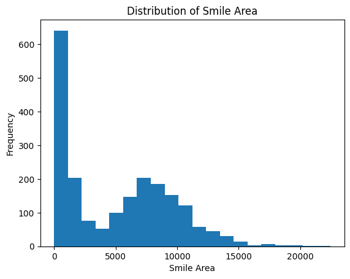

```python
# prompt: Using dataframe test_smile_clean: distribution

import matplotlib.pyplot as plt
# Create a histogram of the 'smile_area' column
plt.hist(test_smile_clean['smile_area'], bins=20)  # Adjust the number of bins as needed
plt.xlabel('Smile Area')
plt.ylabel('Frequency')
plt.title('Distribution of Smile Area')
plt.show()
```

# For fun -- Trying to caclulate Jackson and Collin's smiles

- I read in their pictures and then extract the mouth points just to add some finality to the presentation.

```python
image_dir = '/content/drive/MyDrive/seth_final/j&c'
save_dir = '/content/drive/MyDrive/seth_final/'

if not os.path.exists(image_dir):
    print(f"Image directory not found: {image_dir}")
else:
    image_files = [os.path.join(image_dir, file) for file in os.listdir(image_dir)]


    image_files_subset = image_files[0:2]

def process_images(image_files_subset):
    smile_list = []
    filenames = []

    for file in image_files_subset:
        try:
            mouth_points = measure_smile(file)
            smile_list.append(mouth_points)
        except cv2.error:
            smile_list.append(None)

        filenames.append(os.path.basename(file))

    subset_df = pd.DataFrame({'file': filenames, 'mouth_points': smile_list})

    subset_save_path = os.path.join(save_dir, "j_and_c2.csv")
    subset_df.to_csv(subset_save_path, index=False)
    print(f"Subset data saved to {subset_save_path}")

process_images(image_files_subset)
```

```
Subset data saved to /content/drive/MyDrive/seth_final/j_and_c2.csv
```

Reading back in this dataframe to run find the area for each of them.

```python
jackson_collin = pd.read_csv("/content/drive/MyDrive/seth_final/j_and_c2.csv")
```

```python
mouth_area_list = []
for i in range(0, len(jackson_collin)):
    try:
        # 1. Extract the string and split it based on newline characters
        mouth_points_str = jackson_collin['mouth_points'][i]
        points_list = mouth_points_str.strip('').split('\n')  # Split by newline

        # 2. Clean each point string and convert to integers
        mouth_points = []
        for point_str in points_list:
            point_str = point_str.strip().replace('[', '').replace(']', '')
            if len(point_str) > 0:  # Skip empty strings
                x, y = map(int, point_str.split())  # Split by space and convert to int
                mouth_points.append([x, y])

        # 3. Convert to a NumPy array
        mouth_points = np.array(mouth_points)

        # 4. Now you can perform the calculations (if there are enough points)
        if len(mouth_points) > 12:
            mouth_area = 0.5 * np.abs(np.dot(mouth_points[12:, 0], np.roll(mouth_points[12:, 1], 1)) -
                                      np.dot(mouth_points[12:, 1], np.roll(mouth_points[12:, 0], 1)))
            mouth_area_list.append(mouth_area)
        else:
            print(f"Skipping row {i} due to insufficient mouth points.")
            mouth_area_list.append(0)

    except (TypeError, ValueError, IndexError) as e:
        print(f"Error processing row {i}: {e}")
        mouth_area_list.append(0)

jackson_collin['smile_area'] = mouth_area_list
```

Producing the final results for Jackson and Collin.

```python
jackson_collin
```

|  | file | mouth_points | smile_area |
| --- | --- | --- | --- |
| 0 | collin.png | [[238 402]\n [258 393]\n [274 397]\n [288 392]... | 89.5 |
| 1 | jackson.png | [[237 291]\n [251 289]\n [262 291]\n [274 289]... | 381.5 |

## **Discussion**

While conducting this project, I learned a lot about the process of using computer vision and facial recognition and produced a pretty fun final product. I also incorporated some friendly faces into the presentation to both make it a little more relatable for our class, as well as testing myself for downloading images and seeing if the formula works the same.

Jackson and Collin's smiles are on the low end of the output compared to the NFL players, but there are many different factors for this.

First, I found that there are a couple of difficulties that the facial recognition code experiences. For one, I saw firsthand how it has difficulty with facial hair. Jackson's smile is a little hard to detect because of his mustache and perhaps his beard as well. He was not the only player in the data that was affected by this. Secondly, I noticed something that Thomas Nestico also noticed in his original project, which was that players who have similar skin tones as their lips often recieve a very low area score due to difficulty in picking up the smile.

In all, I think this project really gave me some great insight into what can be achieved with computer visison and could be reproduced to a number of different datasets in the future. Though the area of a smile is not necessarily too important in a lot of cases, the basic principles I learned and used will help me going forward in other computer vision related projects and research.

```python
%%shell
jupyter nbconvert --to html /content/Seth_Writeup_Duffy.ipynb
```